**PRM Release MillFrame 4.1.0**

**PRM Client Administration User Guide**

Confidential and Proprietary

© 2016 Milliman, Inc. All rights reserved.  
Milliman® is a trademark of Milliman, Inc.  
All other trademarks belong to their respective owners

This manual and its contents are the confidential property of Milliman, Inc. and are prepared for the exclusive use of Milliman, Inc. and its subscribing clients. Any distribution or reproduction, intentional or unintentional, of any materials contained herein without the express written permission of Milliman, Inc. is prohibited.

**Introduction**

Milliman PRM Analytics is a predictive analytics solution capable of predicting any number of healthcare management risks. The primary predictive analytics are the Opportunity Prospective Scores.

Milliman PRM Analytics is not a standalone solution. It can also be integrated with an existing care management system for comprehensive care management. The PRM Care Coordinator Reports provide care managers with a comprehensive view of recent patient clinical and claims activity, making management more efficient and effective.

Milliman PRM Analytics are backed by more than 65 years of experience in healthcare consulting, data analytics, operational analysis and problem solving. The solutions offered by this tool leverage a unique reporting structure and custom analytics that help meet coming healthcare challenges head on.

This user guide is designed to give users an understanding of the latest features of the PRM Client Administration Console and step by step instructions for using the system.

Please note that these instructions are ONLY meant for client users who have been granted access.

*Note: Access to various functionality is dictated by what was enabled for the role assigned to the user and the options enabled for the client. For illustration purposes, all of the functionality is enabled in the screen shots shown below.*

**Technical Support**

If you are having any technical difficulty with the product, please contact our technical support team by email: *prm.support@milliman.com*

*Note: For the purpose of this user guide, all data has been de-identified to protect patients personal health information (PHI) in accordance with the Health Insurance Portability and Accountability Act of 1996 (HIPAA).*

## PRM Client Administrator Console

## Overview

Millframe 4.1.0 is an application that allows the Milliman administrators to add and manage users, and set different roles for the users. It allows the Client Administrators to add and manage users, and set data restrictions for them. The Client users can view the Qlikview reports using Web Portal interface. The application also allows the Client Publisher to publish the contents for a Client. The application Millframe consists of five modules. The PRM Web Portal module allows the client users to view the reports for the group(s) they are associated with.

## Definitions

**Group** – a container used to associate users to reports (QVW). A group may contain any number of users and reports. **Note:** **as a best practice a group should contain exactly 1 report and multiple users; however, this is not enforced programmatically.**

Specific interfaces will not function if associated with a group that contains multiple reports. There interfaces include

- Client administrator console (CAC)
- Client publishing console (CPC)

Both web interfaces could result in personal health information (PHI) leaking due to ambiguous situations if a group containing multiple reports was allowed to be loaded. As a result, both web interfaces actively check to ensure groups contain only one report. One report and multiple users is considered to be a best practice.

**QVW** – A document created by QlikView, BI analysis application; stores a QlikView application, which contains reports, charts, and KPI; used for analyzing data. QVX: QlikView data exchange is a new file/stream format for high performance data input into QlikView. Referred to as a Report.

**Super Group** - A collection of groups. The only groups shown in the Super Group console are groups that only contain 1 QVW.

**Client Publisher** – Console created to allow an authorized person to push updated content to the production server.

**Updated Content** - Content that already exists on production, but is being refreshed with a new data set. **Note: the creation of New Content on the production server requires the involvement of Indianapolis administrators.**

## Getting Started

> A prerequisite for being able to use the **Client Administrator Console** is for the PRM administrator to look at the user’s profile and to make sure that the **Client User Administrator** box has been checked.

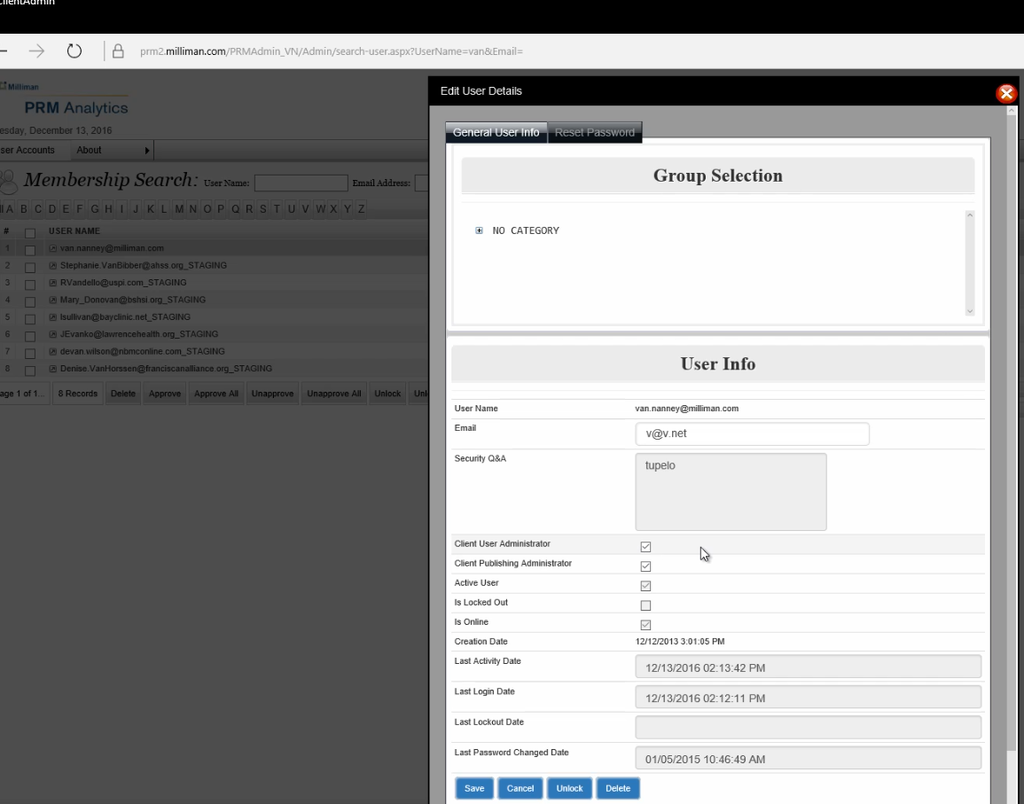

> In this case the box has been checked. So next the Client Administrator logs in to the Web Portal.

[figure not shown]

1. After logging in, the Client Administrator clicks on a specific report from the drop-down menu. For this demo, we will use the New York group report.

   **Note: Only Milliman administrators see a filter box. Client administrator will only have access to their specific reports.**

[figure not shown]

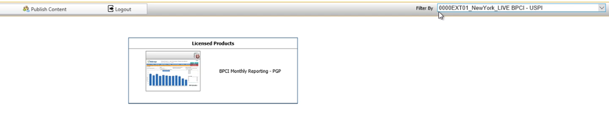

1. This is a list of all the Client-user Administrators for the New York group.

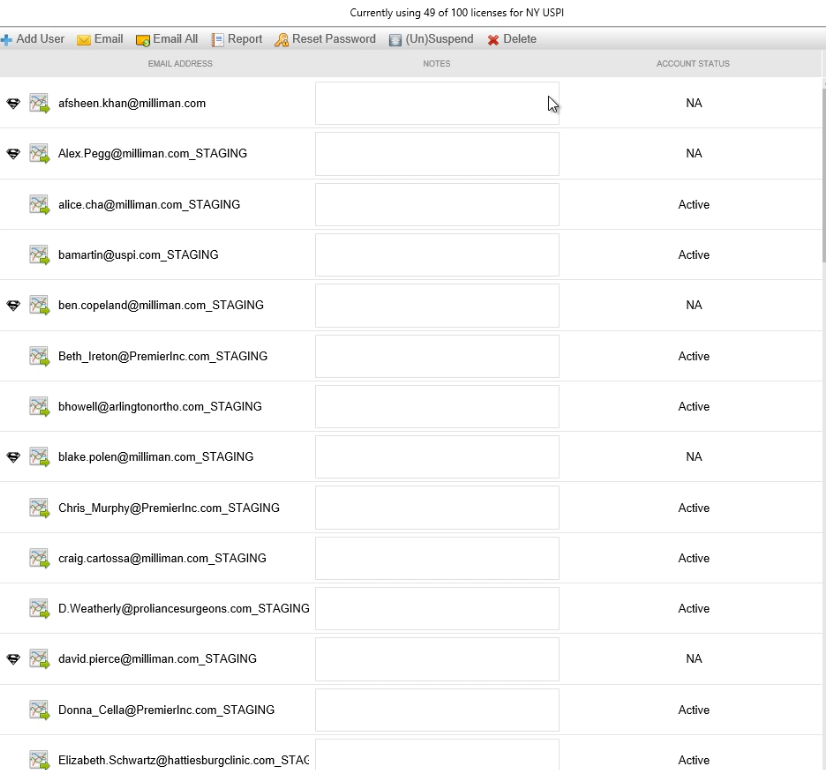

1. The left hand side displays the users also displays their status as client administrators.
2. On the right side of the administrator display page is the data restriction tree. This is where you restrict users’ access to the data.

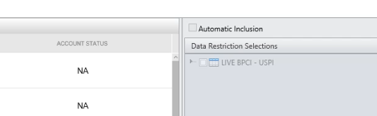

1. As an example we will select one of the Active administrators.

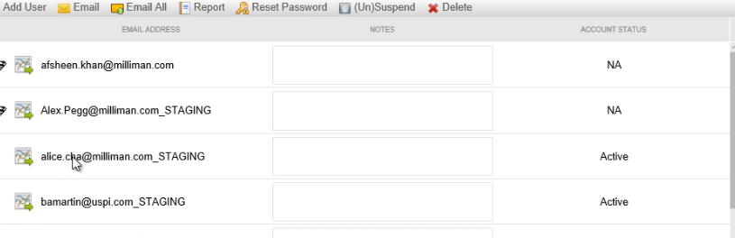

1. When you select a user, the **Restriction Tree** is highlighted. Expanding the tree reveals the access that the client administrator has to different **Providers** within the **Group**. All this information is coming from the QlikView report.

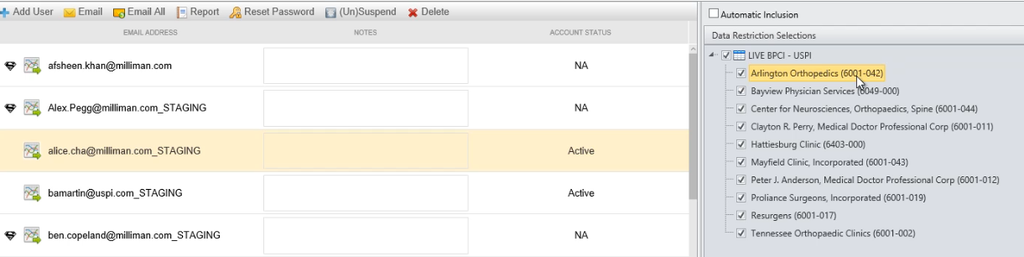

1. Clicking on a different client administrator show the access that they have to different practices.

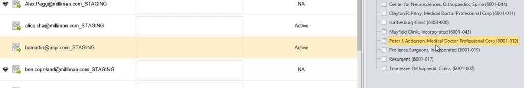

1. When you want to give or restrict access to data, you check or uncheck the boxes of groups you wish to allow or deny access to.

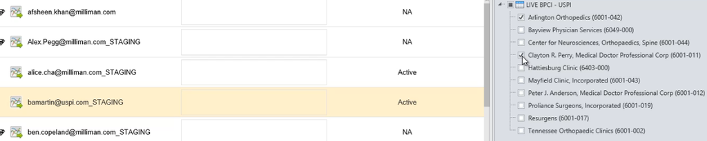

1. When you are finished making your selections, click the **Apply Changes** button.

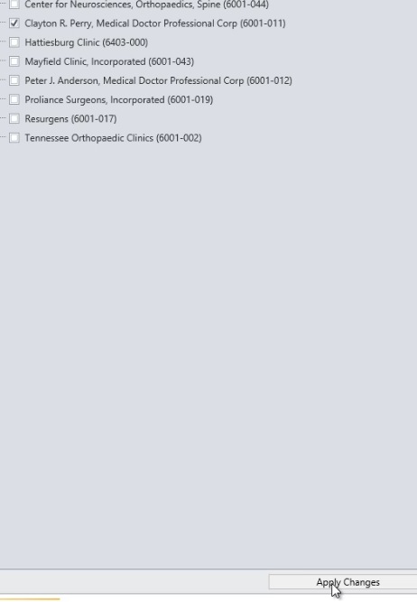

1. The modification to the access takes place. As a shared server it may take a few moments.

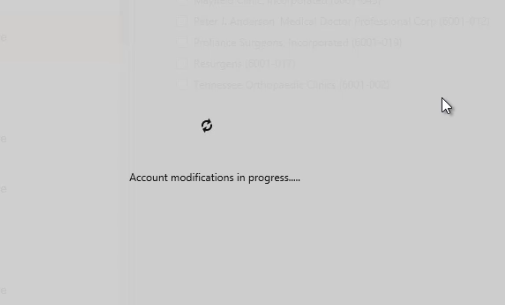

1. When complete, a notification message appears.

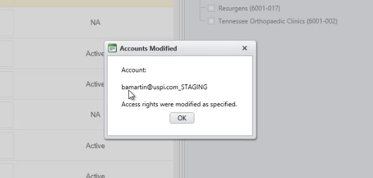

1. So When BA Martin clicks on the Report icon in the Web Portal, they will now have access to the information of both Arlington Orthopedics and Clayton R. Perry.

[figure not shown]

1. Now we will discuss the User view. You will notice that some of the users have little Superman icons to the left of their names. These are **Super Users**.

   No one actually sees these icons but Indianapolis personnel.

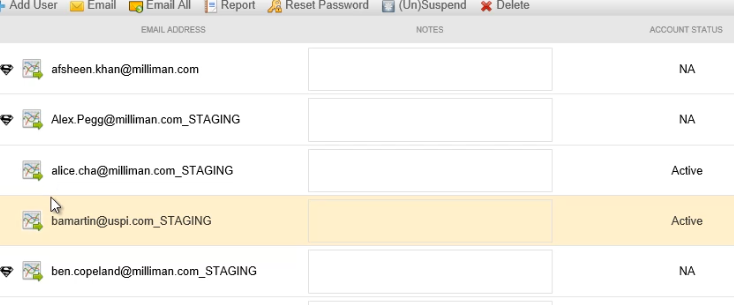

1. When you click on a user’s status, a dialog box appears that tells an administrator the last time the user accessed the system.

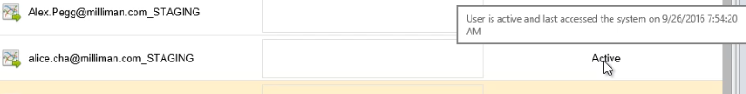

1. Clicking on other users, different messages appear. Below is a test user message.

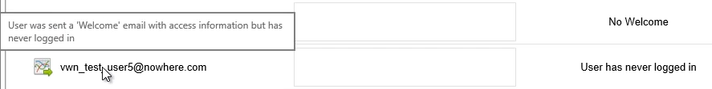

1. The **No Welcome** status means that the user was not sent a welcome message with instructions on how to access the PRM system. Sometimes the user prefers a customized email on access rather than a generic welcome email.

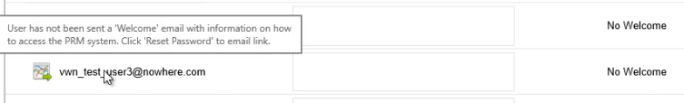

1. Another user status is **Password Reset**. This means either the **User Administrator** has reset the password or the **User** could have clicked the **Reset Password** button on the portal and reset their password.

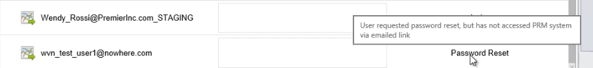

1. There is also a Notes box, where the Client Administrator can add notes; however this may go away in future PRM releases.

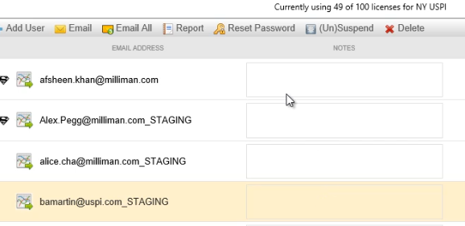

## Client Administrator Toolbar

1. The **Delete** button allows the **Client Administrator** to delete a **User**.

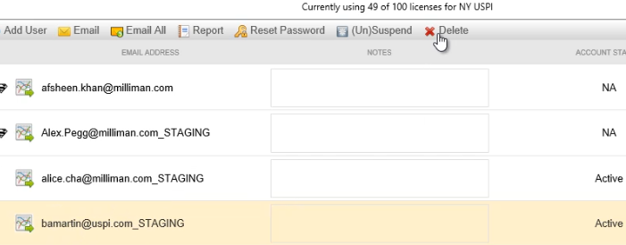

1. Deleting a user doesn’t mean that you have deleted their account from the system. It means that you have removed their access to this report. They may still have access to other reports. **If this is the only report that they have access to, then it will delete their account.**
2. **Suspend/(Un)suspend** will take the user to another area of the report.

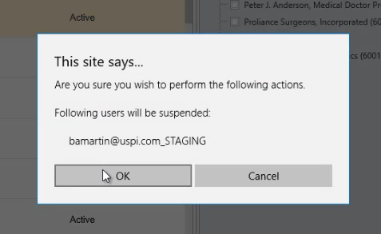

1. When you refresh the screen, it shows that the user’s account has been suspended. When the user’s account has been suspended that are unable to log in to the **Web Portal**.

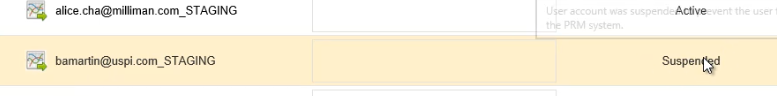

1. **Reset Password**. Clicking on this button will send the User and email telling them to reset their password.

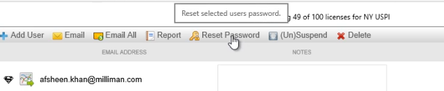

1. Before sending the email, a confirmation box will ask if you want to send the email.

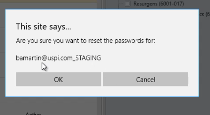

1. **Email All** builds a list for the administrator to send out a group email. **Note: Sometimes the group list is so long that it exceeds the email limit of the email client. So there is a possibility that some users may not receive the blanket email.**

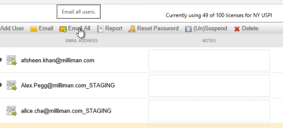

> 26. **Email** is used to email an individual user.

> 27. **Add User**.

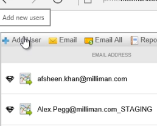

1. When you click on this button it takes you to a new screen.

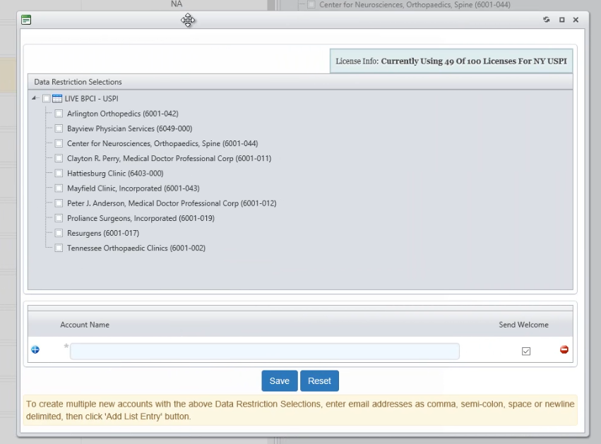

1. This gives you a **Restriction Tree** and a drop down where you can add a new user.

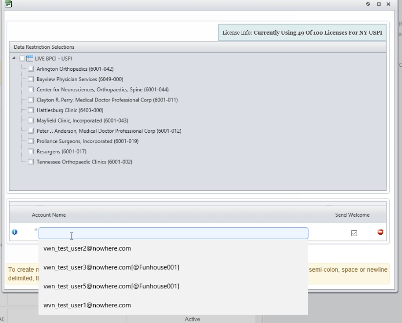

1. After adding the user in the box, you click **Save**.

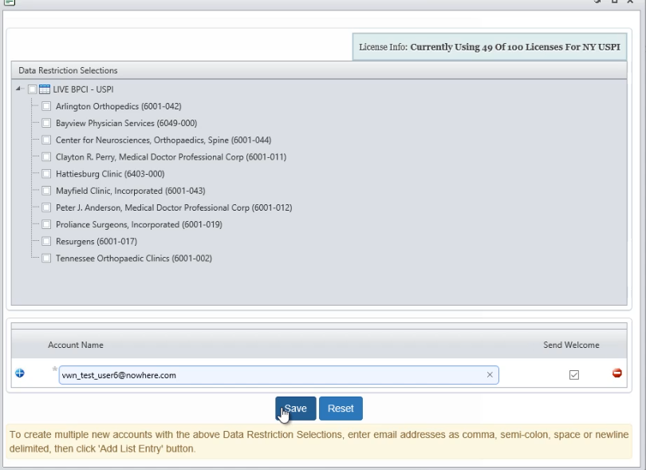

1. Before hitting **Save,** you must make **Data Restrictions Selections** from the list.

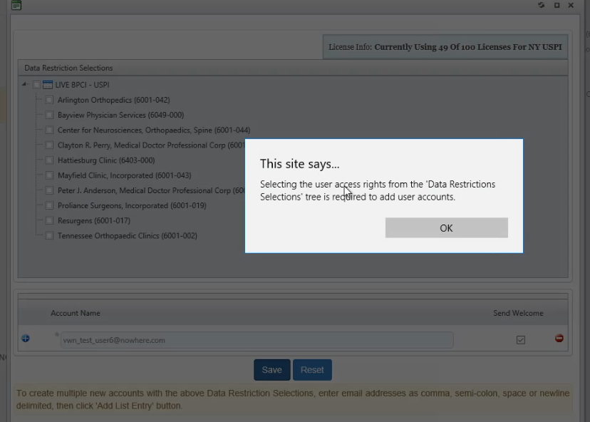

1. After saving, the site sends a confirmation message.